# Relazione di fisica

### esprimento sulla riflessione

## 1 - Riflessione su uno specchio piano

Disporre lo specchio lungo MN (O si trovi sul centro O dello specchio). Collocare la sorgente del pennello luminoso in modo che il raggio incida in O lo specchio. Siano ⍺ e β rispettivamente l’angolo di incidenza e l’angolo di riflessione di vertice nel punto di incidenza O. Con gli spilli segna la direzione dei raggi incidente e riflesso.

Riportare i dati raccolti in questa tabella

| α | β |
| --- | --- |
| 0 | 0 |
| 10 | 10 |
| 20 | 20 |
| 30 | 30 |
| 40 | 40 |

> **Richieste:**
1. **rappresenta** i dati in un **diagramma cartesiano (α,β)**
2. α = β ?

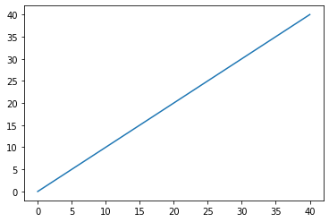

```python
import matplotlib.pyplot as plt
import numpy as np

x = [0,10,20,30,40]; y = x
plt.plot(x,y); plt.show()
```

2. α = β si sono uguali (entro le incertezze sperimentali)

### esperimenti sulla rifrazione

## 2 - passaggio della luce dall’aria al plexiglas

| α | β | sin α | sin β |
| --- | --- | --- | --- |
| 0 | 0 | 0 | 0 |
| 10 | 8 | 0,17 | 0,14 |
| 20 | 10 | 0,34 | 0,17 |
| 30 | 16 | 0,50 | 0,27 |
| 40 | 24 | 0,64 | 0,41 |

> **Richieste:**
1. **Il raggio rifratto** si **avvicina** o si **allontana** dalla **normale in O**?
2. Quanto vale **l’angolo di rifrazione** se quello di **incidenza è nullo**?
3. **Rappresentare graficamente** in un **diagramma cartesiano i dati (senα , senβ)**

```
Valori di K (non costanti)
1.2477136491825187
1.9696155060244163
1.81397763927165
1.58035333336502
```

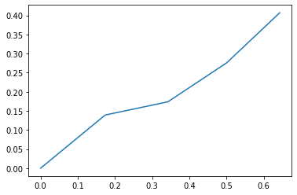

```python
import math
xsina,ysinb = [],[]
x = [0,10,20,30,40]; y = [0,8,10,16,24]
for i in range (0,len(x)):
    xsina.append(math.sin(math.radians(x[i])))
    ysinb.append(math.sin(math.radians(y[i])))

print("Valori di K (non costanti)")
for i in range(1,len(x)):
    print(float(xsina[i])/float(ysinb[i]))

plt.plot(xsina,ysinb); plt.show()
```

## 3 - passaggio dal plexiglas all’aria: riflessione totale

Procedere come per l’esperimento precedente, facendo incidere il raggio di luce sulla superficie curva del semicilindro di plexiglas, in modo che il raggio emerga dal punto O. Fare incidere il raggio con varie inclinazioni e segnare con spilli le direzioni dei raggi incidenti e rifratti passanti per il punto O. Per quale valore di α il raggio rifratto diventa parallelo alla superficie di separazione plexiglas-aria? Indicarlo con α L angolo limite e annotarlo nell’ultima riga della tabella sottostante. Cosa succede aumentando il valore dell’angolo di incidenza oltre l’angolo α L ? Misurare gli angoli ⍺ e β rispettivamente di incidenza e di rifrazione di vertice nel punto di incidenza O. Completare la tabella:

[output not shown]

> **Richieste:**
1. Il **raggio rifratto** si **avvicina o si allontana** dalla normale in O?
2. Quanto vale **l’angolo di rifrazione** se quello di **incidenza è nullo**?
3. Rappresentare graficamente in **un diagramma cartesiano i dati (senα , senβ)**
4. Entro le incertezze sperimentali delle misure, **il grafico** risponde alla **condizione senα/senβ=k’ costante**?
5. Quale **valore** puoi attribuire a **k’**?
6. Quale **relazione sussiste tra k e k’ e sen L** ?

> **Risposte:**
1. **Si** il raggio rifratto **si allontana da O**
2. β = 0 poichè **n2*sin(β) = n1*sin(0)**
3. **No** k' **non è costante**

```
Valori di K (non costanti)
0.5619373070991475
0.6279758176279673
0.6433797829465836
0.6571478672588068
```

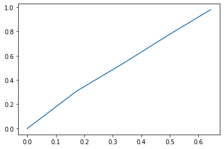

```python
import math
xsina,ysinb = [],[]
x = [0,10,20,30,40]; y = [0,18,33,51,78]
for i in range (0,len(x)):
    xsina.append(math.sin(math.radians(x[i])))
    ysinb.append(math.sin(math.radians(y[i])))

print("Valori di K (non costanti)")
for i in range(1,len(x)):
    print(float(xsina[i])/float(ysinb[i]))

plt.plot(xsina,ysinb); plt.show()
```